# Exponential Distribution

April 23, 2020

## Chapter 6

**Section 6.5**

## Exponential Distribution

*Definition.*

Let \( \small X \) be a continuous random variable and let \( \small \lambda > 0 \). Then, \( \small X \) follows an **Exponential distribution** if the pdf of \( \small X \) is given by

\[ f(x) =\large \lambda e^{-\lambda x}1_{(0,\infty)}(x) \]

We write \( X \sim Exp(\lambda) \).

*Notes.*

(1) Useful for modeling random variables that measure the *time* until an event occurs.

- time it takes for a capacitor to fail
- time it takes to observe your first crow of the day

(2) Related to Poisson process

### The Exponential Distribution

For \( X \sim Exp(\lambda) \)

\[ f(0) = \lambda \quad \quad \lim\limits_{x\to \infty}f(x) = 0 \]

Here is a visualization letting \( \lambda = 0.5 \).

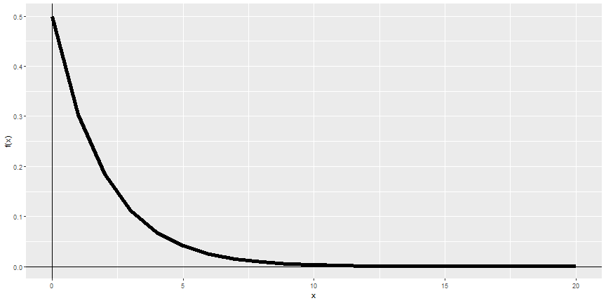

### CDF of Exponential

\[ F(x) = P(X \leq x) = \int\limits_{-\infty}^{x}f(t)dt = \begin{cases} 0 & x \leq 0 \\ \int\limits_{0}^{x}\lambda e^{-\lambda t}dt & x > 0 \end{cases} \]

Solve:

\[ \begin{aligned} \int\limits_{0}^{x}\lambda e^{-\lambda t}dt &= \lambda\left.\left(-\frac{1}{\lambda}e^{-\lambda t}\right)\right|_{0}^{x} \\ &= \lambda\left(-\frac{1}{\lambda}e^{-\lambda x}\right) - \lambda\left(-\frac{1}{\lambda}e^{-\lambda \cdot 0}\right) \\ &= 1 - e^{-\lambda x} \end{aligned} \]

Then, we can write the cdf compactly as

\[ F(x) = (1-e^{-\lambda x})1_{(0,\infty)} \]

### CDF of Exponential

\[ F(x) = (1-e^{-\lambda x})1_{(0,\infty)} \]

A graph of the cdf when \( \lambda = 0.5 \). There is an horizontal asymptote at \( 1 \).

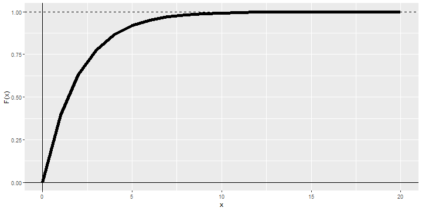

*Note.*

\[ 1 - F(x) = P(X > x) = \begin{cases} 1 & x \leq 0 \\ e^{-\lambda x} & x > 0 \end{cases} \]

## Exponential Distribution Results

*Result.*

Let \( \small X \sim Exp(\lambda) \). Then,

(1) \[ E[X] = \frac{1}{\lambda} \]

(2) \[ V[X] = \frac{1}{\lambda^2} \]

### Proof of Expectation of the Exponential Distribution

I provide the proof of the expectation. This requires the use of integration by parts. I would like to ask that you prepare a solution of the variance, which requires proof by parts twice and proceeds very closely to what is presented below.

### Proof of \( E[X] \) for \( X \sim Exp(\lambda) \)

\[ \begin{aligned} E[X] &= \int\limits_{-\infty}^{\infty}xf(x)dx = \int\limits_{0}^{\infty}x\lambda e^{-\lambda x}dx \quad \#\text{cdf and limits} \\ &= \lambda\int\limits_{0}^{\infty}xe^{-\lambda x}dx \end{aligned} \]

To solve this integral, we need to use integration by parts. I always relate integration by parts to the chain-rule of differentiation, which I always remember. First, we set

\[ \begin{aligned} u = x \quad & \quad du = dx \\ dv = e^{-\lambda x}dx \quad & \quad v = -\frac{1}{\lambda}e^{-\lambda x} \end{aligned} \]

Recall from the chain rule that if we have function \( u(x) \) and \( v(x) \), then

\[ (uv)^{'} = u'v + v'u \]

### Proof of Expectation of the Exponential Distribution

\[ \begin{aligned} u = x \quad & \quad du = dx \\ dv = e^{-\lambda x}dx \quad & \quad v = -\frac{1}{\lambda}e^{-\lambda x} \end{aligned} \]

Recall from the chain rule that if we have function \( u(x) \) and \( v(x) \), then

\[ (uv)^{'} = u'v + v'u \]

Then taking the anti-derivative of each side, we show that

\[ \int u'v + \int v'u = \int (uv)^{'} = uv \]

Where I am being 'sloppy' in my notation (everything here could be \( u(x), v(x) \) with integration respect to \( x \), or \( dx \)). Rearranging gives the rule commonly known as *integration by parts*.

\[ \int v'u = uv - \int u'v \]

Applying the decomposing 'parts' given at the top of the slide shows us that

\[ \int\limits_{0}^{\infty}xe^{-\lambda x}dx = \left.-\frac{x}{\lambda}e^{-\lambda x}\right|_0^{\infty} - \int\limits_{0}^{\infty}-\frac{1}{\lambda}e^{-\lambda x}dx = \left.-\frac{x}{\lambda}e^{-\lambda x}\right|_0^{\infty} + \int\limits_{0}^{\infty}\frac{1}{\lambda}e^{-\lambda x}dx \]

### Proof of Expectation of the Exponential Distribution

We are now left with solving

\[ \int\limits_{0}^{\infty}xe^{-\lambda x}dx = \left.-\frac{x}{\lambda}e^{-\lambda x}\right|_0^{\infty} + \int\limits_{0}^{\infty}\frac{1}{\lambda}e^{-\lambda x}dx \]

of which we can now directly solve the integral on the right hand side of the equation.

\[ \frac{1}{\lambda}\int\limits_{0}^{\infty}e^{-\lambda x}dx = \left.\frac{1}{\lambda}\left(-\frac{1}{\lambda}e^{-\lambda x}\right)\right|_0^{\infty} = \left.-\frac{1}{\lambda^2}e^{-\lambda x}\right|_0^{\infty} \]

Thus,

\[ \int\limits_{0}^{\infty}xe^{-\lambda x}dx = \left.-\frac{x}{\lambda}e^{-\lambda x}\right|_0^{\infty} - \left.\frac{1}{\lambda^2}e^{-\lambda x}\right|_0^{\infty} \]

All that is left is to apply the functions at the limits of the integrand.

### Proof of Expectation of the Exponential Distribution

Returning to our proof, we can now state

\[ \begin{aligned} E[X] &= \lambda\int\limits_{0}^{\infty}xe^{-\lambda x}dx \\ &= \lambda \left.\left(-\frac{x}{\lambda}e^{-\lambda x} -\frac{1}{\lambda^2}e^{-\lambda x}\right)\right|_0^{\infty} \\ &= \left.\left(-xe^{-\lambda x} -\frac{1}{\lambda}e^{-\lambda x}\right)\right|_0^{\infty} \\ &= \lim\limits_{x\to \infty}\left(-xe^{-\lambda x} -\frac{1}{\lambda}e^{-\lambda x}\right) - (-0e^0 - \frac{1}{\lambda}e^{-\lambda \cdot 0}) \\ &= \lim\limits_{x\to \infty}\left(-xe^{-\lambda x} -\frac{1}{\lambda}e^{-\lambda x}\right) + \frac{1}{\lambda} \end{aligned} \]

Where

\[ \lim\limits_{x\to \infty}\left(-xe^{-\lambda x} + -\frac{1}{\lambda}e^{-\lambda x}\right) = 0 \]

We finish the proof by showing this result.

### Proof of Expectation of the Exponential Distribution

It is clear that

\[ \lim\limits_{x\to \infty}\left(-\frac{1}{\lambda}e^{-\lambda x}\right) = 0 \]

However, we must apply a little more effort to the first limit because

\[ \lim\limits_{x\to \infty}-xe^{-\lambda x} = \lim\limits_{x\to \infty}-\frac{x}{e^{\lambda x}} \]

has limits \( \infty/\infty \), thus we must apply *L'Hopital's Rule*.

\[ \lim\limits_{x\to \infty}-xe^{-\lambda x} = \lim\limits_{x\to \infty}-\frac{x}{e^{\lambda x}} = \lim\limits_{x\to \infty}-\frac{1}{\lambda e^{\lambda x}} = 0 \]

We thus achieve our solution that

\[ E[X] = \lambda\int\limits_{0}^{\infty}xe^{-\lambda x}dx = \frac{1}{\lambda} \]

To prove the *variance* component you need to use *integration by parts* twice to show that

\[ E[X^2] = \lambda\int\limits_{0}^{\infty}x^2e^{-\lambda x}dx = \frac{2}{\lambda^2} \]

### Exponential Distribution Example

Suppose that the time \( \small X \) in minutes from midnight until the next customer enters Walmart follows an exponential distribution with rate \( \small\lambda = 0.4 \).

\[ X \sim Exp(0.4) \]

### Find \( \small E[X] \) and \( \small V[X] \)

Using the previous results

\[ E[X] = \frac{1}{\lambda} = \frac{1}{0.4} = 2.5 \text{ minutes} \]

This is interpreted as the average time until the next customer arrives (in minutes past midnight).

\[ V[X] = \frac{1}{\lambda^2} = \frac{1}{(0.4)^2} = 6.25 \text{ minutes}^2 \]

or, in units of minutes,

\[ \sigma_X = \sqrt{\sigma^2_X} = \sqrt{6.25} = 2.5 \text{ minutes} \]

### Exponential Distribution Example Continued

\[ \]

\[ X \sim Exp(0.4) \]

### What is the probability the first customer walks in between \( 2 \) and \( 5 \) minutes after midnight?

Make use of the cdf for the exponential distribution here,

\[ \begin{aligned} P(2 \leq X \leq 5) &= P(X \leq 5) - P(X \leq 2) \\ &= (1 - e^{-0.4(5)}) - (1 - e^{-0.4(2)}) \\ &= e^{-0.8} - e^{-2.0} \approx 0.3140 \end{aligned} \]

### Memoryless Property of Exponential Distribution

Given that a customer has not arrived in the first \( 2 \) minutes, what is the probability it will take another \( 5 \) minutes before the first customer arrives?

\[ \begin{aligned} P(X > 2 + 5 | X > 2) &= \frac{P(X > 7)}{P(X > 2)} \\ &= \frac{e^{-0.4(7)}}{e^{-0.4(2)}} \\ &= e^{-0.4(5)} = P(X > 5) \end{aligned} \]

Thus, this distribution also 'forgets' about what has previously occurred. All '5' minute intervals, given the event has not occurred previously, will have the same probability.